# R-Ladies East Lansing

dplyr key

## Load libraries

```r
library(tidyverse)
library(nycflights13)
```

### Import data

```r
flights <- flights
flights
```

```
## # A tibble: 336,776 x 19
##     year month   day dep_time sched_dep_time dep_delay arr_time
##    <int> <int> <int>    <int>          <int>     <dbl>    <int>
##  1  2013     1     1      517            515         2      830
##  2  2013     1     1      533            529         4      850
##  3  2013     1     1      542            540         2      923
##  4  2013     1     1      544            545        -1     1004
##  5  2013     1     1      554            600        -6      812
##  6  2013     1     1      554            558        -4      740
##  7  2013     1     1      555            600        -5      913
##  8  2013     1     1      557            600        -3      709
##  9  2013     1     1      557            600        -3      838
## 10  2013     1     1      558            600        -2      753
## # … with 336,766 more rows, and 12 more variables: sched_arr_time <int>,
## #   arr_delay <dbl>, carrier <chr>, flight <int>, tailnum <chr>,
## #   origin <chr>, dest <chr>, air_time <dbl>, distance <dbl>, hour <dbl>,
## #   minute <dbl>, time_hour <dttm>
```

```r
weather <- weather
weather
```

```
## # A tibble: 26,115 x 15
##    origin  year month   day  hour  temp  dewp humid wind_dir wind_speed
##    <chr>  <int> <int> <int> <int> <dbl> <dbl> <dbl>    <dbl>      <dbl>
##  1 EWR     2013     1     1     1  39.0  26.1  59.4      270      10.4
##  2 EWR     2013     1     1     2  39.0  27.0  61.6      250       8.06
##  3 EWR     2013     1     1     3  39.0  28.0  64.4      240      11.5
##  4 EWR     2013     1     1     4  39.9  28.0  62.2      250      12.7
##  5 EWR     2013     1     1     5  39.0  28.0  64.4      260      12.7
##  6 EWR     2013     1     1     6  37.9  28.0  67.2      240      11.5
##  7 EWR     2013     1     1     7  39.0  28.0  64.4      240      15.0
##  8 EWR     2013     1     1     8  39.9  28.0  62.2      250      10.4
##  9 EWR     2013     1     1     9  39.9  28.0  62.2      260      15.0
## 10 EWR     2013     1     1    10  41    28.0  59.6      260      13.8
## # … with 26,105 more rows, and 5 more variables: wind_gust <dbl>,
## #   precip <dbl>, pressure <dbl>, visib <dbl>, time_hour <dttm>
```

We can take a look at our data using the `head()` command.

```r
head(flights)
```

```
## # A tibble: 6 x 19
##    year month   day dep_time sched_dep_time dep_delay arr_time
##   <int> <int> <int>    <int>          <int>     <dbl>    <int>
## 1  2013     1     1      517            515         2      830
## 2  2013     1     1      533            529         4      850
## 3  2013     1     1      542            540         2      923
## 4  2013     1     1      544            545        -1     1004
## 5  2013     1     1      554            600        -6      812
## 6  2013     1     1      554            558        -4      740
## # … with 12 more variables: sched_arr_time <int>, arr_delay <dbl>,
## #   carrier <chr>, flight <int>, tailnum <chr>, origin <chr>, dest <chr>,
## #   air_time <dbl>, distance <dbl>, hour <dbl>, minute <dbl>,
## #   time_hour <dttm>
```

### Using `filter()` to isolate rows based off of values

Find all flights departing May 9th

```r
may_9 <- flights %>%
  filter(month == 5 & day == 9)

may_9
```

```
## # A tibble: 981 x 19
##     year month   day dep_time sched_dep_time dep_delay arr_time
##    <int> <int> <int>    <int>          <int>     <dbl>    <int>
##  1  2013     5     9        9           2359        10      359
##  2  2013     5     9      453            500        -7      629
##  3  2013     5     9      515            515         0      755
##  4  2013     5     9      543            545        -2      813
##  5  2013     5     9      545            540         5      839
##  6  2013     5     9      547            600       -13      846
##  7  2013     5     9      553            605       -12      750
##  8  2013     5     9      553            600        -7      805
##  9  2013     5     9      554            600        -6      823
## 10  2013     5     9      554            600        -6      659
## # … with 971 more rows, and 12 more variables: sched_arr_time <int>,
## #   arr_delay <dbl>, carrier <chr>, flight <int>, tailnum <chr>,
## #   origin <chr>, dest <chr>, air_time <dbl>, distance <dbl>, hour <dbl>,
## #   minute <dbl>, time_hour <dttm>
```

Find all flights in January and February

```r
jan_feb <- flights %>%
  filter(month %in% c("1", "2"))

jan_feb
```

```
## # A tibble: 51,955 x 19
##     year month   day dep_time sched_dep_time dep_delay arr_time
##    <int> <int> <int>    <int>          <int>     <dbl>    <int>
##  1  2013     1     1      517            515         2      830
##  2  2013     1     1      533            529         4      850
##  3  2013     1     1      542            540         2      923
##  4  2013     1     1      544            545        -1     1004
##  5  2013     1     1      554            600        -6      812
##  6  2013     1     1      554            558        -4      740
##  7  2013     1     1      555            600        -5      913
##  8  2013     1     1      557            600        -3      709
##  9  2013     1     1      557            600        -3      838
## 10  2013     1     1      558            600        -2      753
## # … with 51,945 more rows, and 12 more variables: sched_arr_time <int>,
## #   arr_delay <dbl>, carrier <chr>, flight <int>, tailnum <chr>,
## #   origin <chr>, dest <chr>, air_time <dbl>, distance <dbl>, hour <dbl>,
## #   minute <dbl>, time_hour <dttm>
```

Find all flights to LAX and SFO.

```r
LAX_SFO <- flights %>%
  filter(dest %in% c("SFO", "LAX"))

LAX_SFO
```

```
## # A tibble: 29,505 x 19
##     year month   day dep_time sched_dep_time dep_delay arr_time
##    <int> <int> <int>    <int>          <int>     <dbl>    <int>
##  1  2013     1     1      558            600        -2      924
##  2  2013     1     1      558            600        -2      923
##  3  2013     1     1      611            600        11      945
##  4  2013     1     1      628            630        -2     1016
##  5  2013     1     1      655            700        -5     1037
##  6  2013     1     1      658            700        -2     1027
##  7  2013     1     1      702            700         2     1058
##  8  2013     1     1      729            730        -1     1049
##  9  2013     1     1      734            737        -3     1047
## 10  2013     1     1      743            730        13     1107
## # … with 29,495 more rows, and 12 more variables: sched_arr_time <int>,
## #   arr_delay <dbl>, carrier <chr>, flight <int>, tailnum <chr>,
## #   origin <chr>, dest <chr>, air_time <dbl>, distance <dbl>, hour <dbl>,
## #   minute <dbl>, time_hour <dttm>
```

Find all flights delayed by > 60min.

```r
flights %>%
  filter(arr_delay >60)
```

```
## # A tibble: 27,789 x 19
##     year month   day dep_time sched_dep_time dep_delay arr_time
##    <int> <int> <int>    <int>          <int>     <dbl>    <int>
##  1  2013     1     1      811            630       101     1047
##  2  2013     1     1      848           1835       853     1001
##  3  2013     1     1      957            733       144     1056
##  4  2013     1     1     1114            900       134     1447
##  5  2013     1     1     1120            944        96     1331
##  6  2013     1     1     1255           1200        55     1451
##  7  2013     1     1     1301           1150        71     1518
##  8  2013     1     1     1337           1220        77     1649
##  9  2013     1     1     1342           1320        22     1617
## 10  2013     1     1     1400           1250        70     1645
## # … with 27,779 more rows, and 12 more variables: sched_arr_time <int>,
## #   arr_delay <dbl>, carrier <chr>, flight <int>, tailnum <chr>,
## #   origin <chr>, dest <chr>, air_time <dbl>, distance <dbl>, hour <dbl>,
## #   minute <dbl>, time_hour <dttm>
```

Find allflights that departed between 12 am and 6 am.

```r
early_flights <- flights %>%
  filter(sched_dep_time >= 2400 |
         sched_dep_time <= 600 )

early_flights
```

```
## # A tibble: 8,970 x 19
##     year month   day dep_time sched_dep_time dep_delay arr_time
##    <int> <int> <int>    <int>          <int>     <dbl>    <int>
##  1  2013     1     1      517            515         2      830
##  2  2013     1     1      533            529         4      850
##  3  2013     1     1      542            540         2      923
##  4  2013     1     1      544            545        -1     1004
##  5  2013     1     1      554            600        -6      812
##  6  2013     1     1      554            558        -4      740
##  7  2013     1     1      555            600        -5      913
##  8  2013     1     1      557            600        -3      709
##  9  2013     1     1      557            600        -3      838
## 10  2013     1     1      558            600        -2      753
## # … with 8,960 more rows, and 12 more variables: sched_arr_time <int>,
## #   arr_delay <dbl>, carrier <chr>, flight <int>, tailnum <chr>,
## #   origin <chr>, dest <chr>, air_time <dbl>, distance <dbl>, hour <dbl>,
## #   minute <dbl>, time_hour <dttm>
```

### Using `arrange()` to sort rows

We can use `arrange()` to sort alphabetically.

```r
flights %>%
  arrange(dest)
```

```
## # A tibble: 336,776 x 19
##     year month   day dep_time sched_dep_time dep_delay arr_time
##    <int> <int> <int>    <int>          <int>     <dbl>    <int>
##  1  2013    10     1     1955           2001        -6     2213
##  2  2013    10     2     2010           2001         9     2230
##  3  2013    10     3     1955           2001        -6     2232
##  4  2013    10     4     2017           2001        16     2304
##  5  2013    10     5     1959           1959         0     2226
##  6  2013    10     6     1959           2001        -2     2234
##  7  2013    10     7     2002           2001         1     2233
##  8  2013    10     8     1957           2001        -4     2216
##  9  2013    10     9     1957           2001        -4     2220
## 10  2013    10    10     2011           2001        10     2235
## # … with 336,766 more rows, and 12 more variables: sched_arr_time <int>,
## #   arr_delay <dbl>, carrier <chr>, flight <int>, tailnum <chr>,
## #   origin <chr>, dest <chr>, air_time <dbl>, distance <dbl>, hour <dbl>,
## #   minute <dbl>, time_hour <dttm>
```

We can use `arrange()` to sort numeric values.

```r
flights %>%
  arrange(air_time)
```

```
## # A tibble: 336,776 x 19
##     year month   day dep_time sched_dep_time dep_delay arr_time
##    <int> <int> <int>    <int>          <int>     <dbl>    <int>
##  1  2013     1    16     1355           1315        40     1442
##  2  2013     4    13      537            527        10      622
##  3  2013    12     6      922            851        31     1021
##  4  2013     2     3     2153           2129        24     2247
##  5  2013     2     5     1303           1315       -12     1342
##  6  2013     2    12     2123           2130        -7     2211
##  7  2013     3     2     1450           1500       -10     1547
##  8  2013     3     8     2026           1935        51     2131
##  9  2013     3    18     1456           1329        87     1533
## 10  2013     3    19     2226           2145        41     2305
## # … with 336,766 more rows, and 12 more variables: sched_arr_time <int>,
## #   arr_delay <dbl>, carrier <chr>, flight <int>, tailnum <chr>,
## #   origin <chr>, dest <chr>, air_time <dbl>, distance <dbl>, hour <dbl>,
## #   minute <dbl>, time_hour <dttm>
```

We can use `desc()` to sort in descending order.

```r
flights %>%
  arrange(desc(air_time))
```

```
## # A tibble: 336,776 x 19
##     year month   day dep_time sched_dep_time dep_delay arr_time
##    <int> <int> <int>    <int>          <int>     <dbl>    <int>
##  1  2013     3    17     1337           1335         2     1937
##  2  2013     2     6      853            900        -7     1542
##  3  2013     3    15     1001           1000         1     1551
##  4  2013     3    17     1006           1000         6     1607
##  5  2013     3    16     1001           1000         1     1544
##  6  2013     2     5      900            900         0     1555
##  7  2013    11    12      936            930         6     1630
##  8  2013     3    14      958           1000        -2     1542
##  9  2013    11    20     1006           1000         6     1639
## 10  2013     3    15     1342           1335         7     1924
## # … with 336,766 more rows, and 12 more variables: sched_arr_time <int>,
## #   arr_delay <dbl>, carrier <chr>, flight <int>, tailnum <chr>,
## #   origin <chr>, dest <chr>, air_time <dbl>, distance <dbl>, hour <dbl>,
## #   minute <dbl>, time_hour <dttm>
```

### Using `mutate()` to add a new column from existing data.

This function is great for performing calculations.

Create a new column named `speed` to calculate miles per hour (using `times` and `miles` columns.

```r
speed <- flights %>%
  mutate(speed = distance/(air_time/60)) %>%
  arrange(desc(speed))

speed
```

```
## # A tibble: 336,776 x 20
##     year month   day dep_time sched_dep_time dep_delay arr_time
##    <int> <int> <int>    <int>          <int>     <dbl>    <int>
##  1  2013     5    25     1709           1700         9     1923
##  2  2013     7     2     1558           1513        45     1745
##  3  2013     5    13     2040           2025        15     2225
##  4  2013     3    23     1914           1910         4     2045
##  5  2013     1    12     1559           1600        -1     1849
##  6  2013    11    17      650            655        -5     1059
##  7  2013     2    21     2355           2358        -3      412
##  8  2013    11    17      759            800        -1     1212
##  9  2013    11    16     2003           1925        38       17
## 10  2013    11    16     2349           2359       -10      402
## # … with 336,766 more rows, and 13 more variables: sched_arr_time <int>,
## #   arr_delay <dbl>, carrier <chr>, flight <int>, tailnum <chr>,
## #   origin <chr>, dest <chr>, air_time <dbl>, distance <dbl>, hour <dbl>,
## #   minute <dbl>, time_hour <dttm>, speed <dbl>
```

What was the longest flight delay in JFK in November?

```r
flights %>%
  filter(month == 11 & origin == "JFK") %>%
  arrange(desc(dep_delay))
```

```
## # A tibble: 8,710 x 19
##     year month   day dep_time sched_dep_time dep_delay arr_time
##    <int> <int> <int>    <int>          <int>     <dbl>    <int>
##  1  2013    11    24     2301           1225       636      149
##  2  2013    11    27     1503            815       408     1628
##  3  2013    11    11     1637           1030       367     1939
##  4  2013    11    24     2117           1530       347       19
##  5  2013    11    24       36           1855       341      325
##  6  2013    11     2     2217           1655       322      114
##  7  2013    11    27     1941           1428       313     2119
##  8  2013    11    27     1342            830       312     1637
##  9  2013    11    26     2237           1730       307      219
## 10  2013    11    17     2357           1920       277      139
## # … with 8,700 more rows, and 12 more variables: sched_arr_time <int>,
## #   arr_delay <dbl>, carrier <chr>, flight <int>, tailnum <chr>,
## #   origin <chr>, dest <chr>, air_time <dbl>, distance <dbl>, hour <dbl>,
## #   minute <dbl>, time_hour <dttm>
```

Which flights departed from LGA arrived to DTW early?

```r
flights %>%
  filter(origin == "LGA" & dest == "DTW") %>%
  arrange(arr_delay)
```

```
## # A tibble: 5,040 x 19
##     year month   day dep_time sched_dep_time dep_delay arr_time
##    <int> <int> <int>    <int>          <int>     <dbl>    <int>
##  1  2013    12    28     1939           1950       -11     2110
##  2  2013     7    14     1623           1630        -7     1748
##  3  2013     8    25     1055           1105       -10     1227
##  4  2013     2    17      848            900       -12     1029
##  5  2013     3    30     1108           1110        -2     1238
##  6  2013     6     1      855            900        -5     1025
##  7  2013     5     5      853            900        -7     1029
##  8  2013     7     7      857            905        -8     1029
##  9  2013     9     1     1620           1625        -5     1748
## 10  2013     1    13      851            905       -14     1031
## # … with 5,030 more rows, and 12 more variables: sched_arr_time <int>,
## #   arr_delay <dbl>, carrier <chr>, flight <int>, tailnum <chr>,
## #   origin <chr>, dest <chr>, air_time <dbl>, distance <dbl>, hour <dbl>,
## #   minute <dbl>, time_hour <dttm>
```

Using `group_by()` and `summarize` to aggregate data.

We can combine multiple rows of data into a single value using `group-by` and `summarize`.

Which airport had the most flights in December?

```r
flights %>%
  filter(month == 12) %>%
  group_by(origin) %>%
  summarise(N_flights = length(flight))
```

```
## # A tibble: 3 x 2
##   origin N_flights
##   <chr>      <int>
## 1 EWR         9922
## 2 JFK         9146
## 3 LGA         9067
```

Which NYC airport has the most airlines?

```r
flights %>%
  group_by(origin) %>%
  summarise(N_airlines = n_distinct(carrier))
```

```
## # A tibble: 3 x 2
##   origin N_airlines
##   <chr>       <int>
## 1 EWR            12
## 2 JFK            10
## 3 LGA            13
```

```r
flights %>%
  filter(origin == "EWR" & carrier == "UA" & dest == "ORD") %>%
  summarise(N_flights = length(flight))
```

```
## # A tibble: 1 x 1
##   N_flights
##       <int>
## 1      3822
```

### Joining data

We can use `inner_join()` to combine data based off of similar values.

```r
weather_flights <- flights %>%
  inner_join(weather)
weather_flights
```

```
## # A tibble: 335,220 x 28
##     year month   day dep_time sched_dep_time dep_delay arr_time
##    <int> <int> <int>    <int>          <int>     <dbl>    <int>
##  1  2013     1     1      517            515         2      830
##  2  2013     1     1      533            529         4      850
##  3  2013     1     1      542            540         2      923
##  4  2013     1     1      544            545        -1     1004
##  5  2013     1     1      554            600        -6      812
##  6  2013     1     1      554            558        -4      740
##  7  2013     1     1      555            600        -5      913
##  8  2013     1     1      557            600        -3      709
##  9  2013     1     1      557            600        -3      838
## 10  2013     1     1      558            600        -2      753
## # … with 335,210 more rows, and 21 more variables: sched_arr_time <int>,
## #   arr_delay <dbl>, carrier <chr>, flight <int>, tailnum <chr>,
## #   origin <chr>, dest <chr>, air_time <dbl>, distance <dbl>, hour <dbl>,
## #   minute <dbl>, time_hour <dttm>, temp <dbl>, dewp <dbl>, humid <dbl>,
## #   wind_dir <dbl>, wind_speed <dbl>, wind_gust <dbl>, precip <dbl>,
## #   pressure <dbl>, visib <dbl>
```

### Advanced dplyr

We can combined what we’ve learned to answer some interesting questions.

Is there a relationship between flight arrival delay and overall trip distance? Or put more simply, Do longer distance flights have a shorter or longer arrival delay?

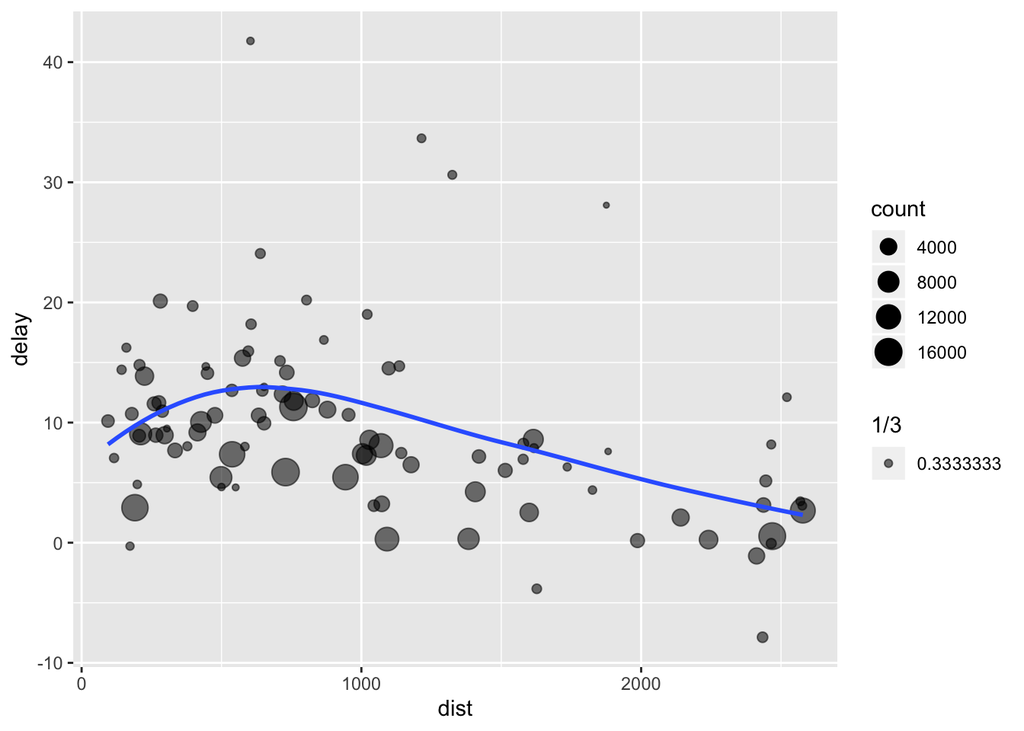

```r
# Code adapted from Hadley Wickham

delays <- flights %>%
  group_by(dest) %>%
  summarise( count = n(),
             dist = mean(distance, na.rm = TRUE),
             delay = mean (arr_delay, na.rm = TRUE)) %>%
  filter(count > 20 & dest != "HNL")



delays %>%
  ggplot(aes(x= dist, y= delay))+
  geom_point(aes(size = count, alpha = 1/3))+
  geom_smooth(se = FALSE)
```

We can see that it appears that there is a slight increase in arrival delays for shorter flights but the delay decreases as you increase the trip distance.